# COPDgene ancestry

Andrey Ziyatdinov

2017-03-07

# 1 About

This document is a quick view on the ancestry data generated in the COPDgene project by running LAMP.

Some questions of the interest include:

- What is the total number of local ancestry segments?
  - Remember that the number of SNPs is around 500K.
  - The number of segments reported in (Parker et al. 2014) is 38,566.
- How long are these segments?
- By doing a PCA model
  - Is PC1 all about the vector of global ancestry?
  - Are the other PCs (2, 3, …) are meaningful?

## 1.1 Updates

(1.1 @ March 6, 2017)

# 2 Computation of ancestry segments

## 2.1 Input data

Input data is a table of 608,917columns (the number of SNPs) and 3,300 rows (the number of individals).

This table was produced from the LAMP output by a custom perl script. It was needed to compute GWAS in COPDgene admixed population within correction by local ancestry per SNP.

A sample of data for first 5 individuals and first 5 SNPs:

```
> acs[1:5, 1:5]
# A tibble: 5 × 5
  chr1acs1 chr1acs2 chr1acs7 chr1acs8 chr1acs10
     <dbl>    <dbl>    <dbl>    <dbl>     <dbl>
1      0.5      0.5      0.5      0.5       0.5
2      0.5      0.5      0.5      0.5       0.5
3      1.0      1.0      1.0      1.0       1.0
4      1.0      1.0      1.0      1.0       1.0
5      0.5      0.5      0.5      0.5       0.5
```

# 3 Load pre-computed data

```r
annot <- copdgene_annot_acs()
```

```r
acsg <- copdgene_acs_global()

acsg <- mutate(acsg,
  acs_gr = cut(acs_global, breaks = c(0, 0.7, 0.8, 0.9, 1)))
```

Two variables are used from the `acsg` table:

- `acs_global`: a continious measure of global ancestry (range from 0 to 1)
- `acs_gr`: a factor variable with 4 levels (user here to plot nice figures)

# 4 Global ancestry

Here, we replicate the Figure 1 in (Parker et al. 2014).

The dashed red line marks the median value.

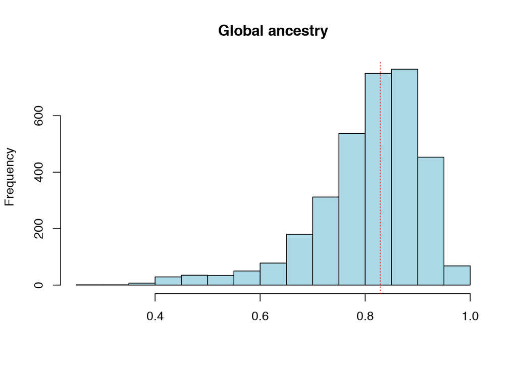

# 5 Annotation for local ancestry

Fields in the annotation table:

- `acs`: ID name of the ancestry segment
- `chr`: Cromosome (1-22)
- `num_snps`: the number of snps in a segment
- `num_ind_diff`: the number of individuals that are different when comparing the current and the next ancestry segments
  - `NA` values mean that that segment was the last in Chromosome
- `length_bp`: the length of segment measured in bp
- `length_cM`: the length of segment measured in cM (converted from `bp` by simply dividing by 1M)

## 5.1 The number of ancestries

| N | Source |
| --- | --- |
| 154,042 | All segments computed here |
| 37,194 | A subset of segments computed here (> 10kbp) |
| 38,566 | (Parker et al. 2014) |

## 5.2 Ordered by the number of snps

| acs | chr | num_snps | num_ind_diff | length_bp | length_cM |
| --- | --- | --- | --- | --- | --- |
| acs69505 | 7 | 380 | NA | 1,886,589 | 1.887 |
| acs43029 | 4 | 371 | NA | 1,792,720 | 1.793 |
| acs77262 | 8 | 327 | NA | 2,305,923 | 2.306 |
| acs51438 | 5 | 243 | NA | 1,107,550 | 1.108 |
| acs34063 | 4 | 179 | 1 | 1,085,574 | 1.086 |
| acs69506 | 8 | 169 | 3 | 450,133 | 0.450 |

## 5.3 Ordered by the length

| acs | chr | num_snps | num_ind_diff | length_bp | length_cM |
| --- | --- | --- | --- | --- | --- |
| acs80438 | 9 | 21 | 13 | 31,151,975 | 31.152 |
| acs5765 | 1 | 4 | 2 | 22,664,974 | 22.665 |
| acs127202 | 16 | 31 | 1 | 10,798,520 | 10.799 |
| acs28940 | 3 | 28 | 4 | 4,990,231 | 4.990 |
| acs148445 | 21 | 35 | 25 | 4,433,771 | 4.434 |
| acs64946 | 7 | 13 | 1 | 4,245,615 | 4.246 |

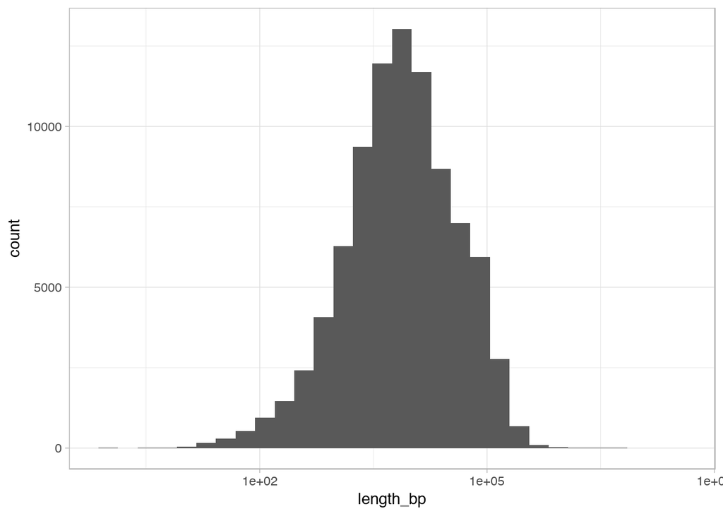

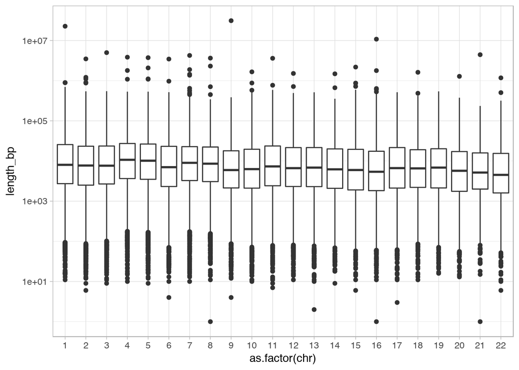

Note the log10 scale on Y on the figure above.

## 5.4 Ordered by the number of ind. diff.

| acs | chr | num_snps | num_ind_diff | length_bp | length_cM |
| --- | --- | --- | --- | --- | --- |
| acs53898 | 6 | 1 | 623 | 0 | 0.000 |
| acs54237 | 6 | 2 | 562 | 1,437 | 0.001 |
| acs11043 | 2 | 2 | 246 | 2,855 | 0.003 |
| acs53896 | 6 | 1 | 182 | 0 | 0.000 |
| acs54230 | 6 | 5 | 179 | 10,510 | 0.011 |
| acs11150 | 2 | 1 | 163 | 0 | 0.000 |

```r
table(annot$num_ind_diff > 1)
```

```
FALSE  TRUE
76303 77717
```

# 6 PCA model on local ancestry

The R code is given below.

```r
library(rsvd)

acs <- copdgene_acs(acs_size = 10e3)

acs_c <- scale(acs, center = T, scale = F)

mod <- rsvd(acs_c, k = 10)

ev <- mod$v
scores <- mod$u %*% diag(mod$d)

varexp <- mod$d^2 / sum(mod$d^2)
```

## 6.1 Explained variance

The total variance was approximated by the first 10 PCs.

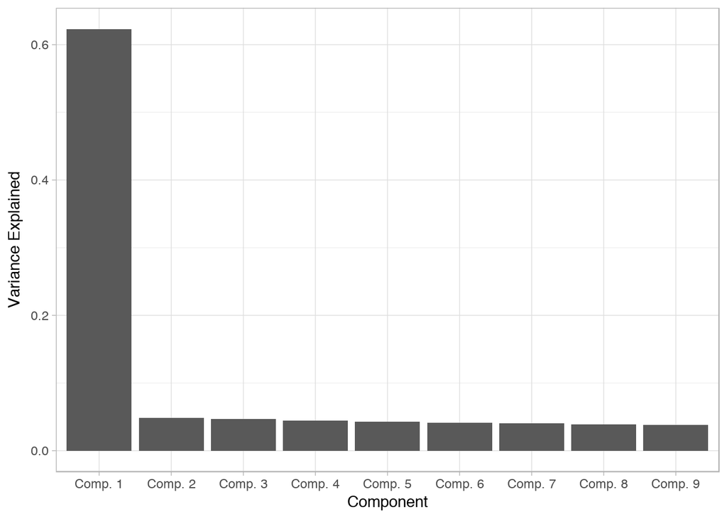

## 6.2 Scatterplots on PCs

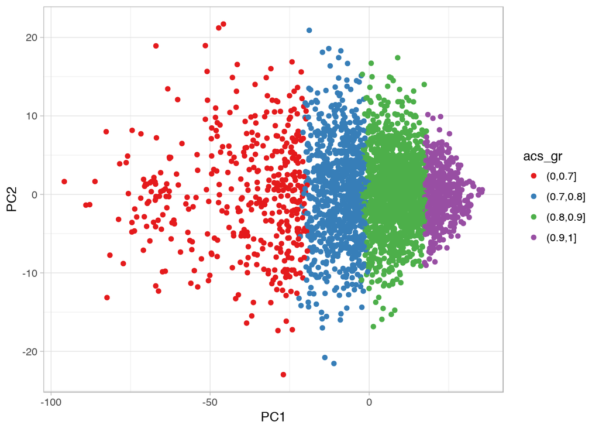

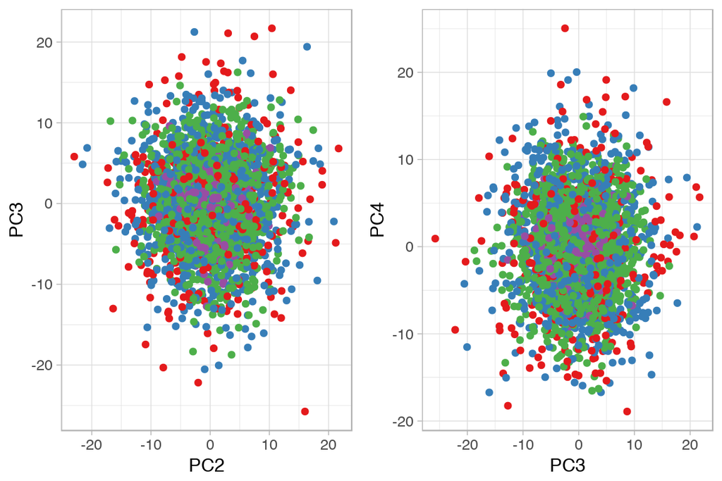

## 6.3 PCs vs. global ancestry

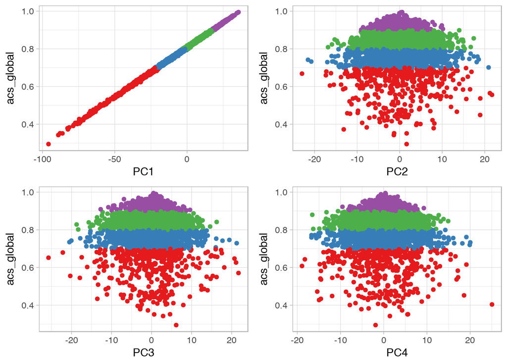

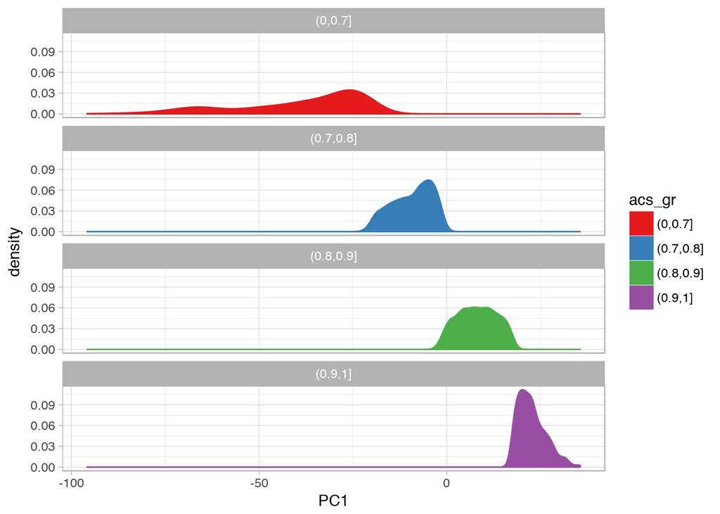

# 7 Ancestry association mapping to replicate 12q14.1 locus

(Parker et al. 2014) conducted genome-wide association analysis for `FEV1/FVC` phenotype using 38,566 ancestry segments. The genome-wide significant signal was established at 12q14.1 locus, P = 2.1e-6.

Additionally, the same association analysis on `FEV1pp` phenotype showed genome-wide suggestive signal at the same Chr. 12, P = 1.3e-4.

The next fine-mapping analysis using genotype data revealed the most significant SNP rs348644, P = 1.76e-6.

The association results pointed at FAM19A2 gene:

- Start: 61,708,248 bp from pter
- End: 62,279,150 bp from pter
- Size: 570,903 bases

Both phenotypes were corrected by covariates, including:

- `Age_Enroll + gender + BMI + ATS_PackYears + SmokCigNow`
- Global ancestry `acs_global`
- Population structure
  - Parker2014: 4 PCs
    - These 4 PCs would be relevant for analysis of the whole sample, but the question is: whether this corection is relevant for a subset of 3,300 African-Americans.
  - Our analysis: no any PCs (genotype data not available)
    - However, we used the `acs_global` covariate, that will capture that part of population structure related to the african-europenean ancestry.

## 7.1 Base model for association analysis

```r
mod1 <- lm(FEV1_FVC_utah ~ Age_Enroll + gender + BMI +
  ATS_PackYears + SmokCigNow + acs_global, phen)

mod2 <- lm(FEV1pp_utah ~ Age_Enroll + gender + BMI +
  ATS_PackYears + SmokCigNow + acs_global, phen)
```

### 7.1.1 Summaries on base models

`FEV1_FVC_utah`:

```
Call:
lm(formula = FEV1_FVC_utah ~ Age_Enroll + gender + BMI + ATS_PackYears +
    SmokCigNow + acs_global, data = phen)

Residuals:
     Min       1Q   Median       3Q      Max
-0.49650 -0.05826  0.02197  0.08016  0.32827

Coefficients:
                Estimate Std. Error t value Pr(>|t|)
(Intercept)    0.9237373  0.0292714  31.558  < 2e-16 ***
Age_Enroll    -0.0058781  0.0003321 -17.699  < 2e-16 ***
gender2        0.0024305  0.0044235   0.549  0.58274
BMI            0.0034939  0.0003308  10.563  < 2e-16 ***
ATS_PackYears -0.0003895  0.0001017  -3.830  0.00013 ***
SmokCigNow1    0.0750089  0.0058481  12.826  < 2e-16 ***
acs_global    -0.0390208  0.0207293  -1.882  0.05987 .
---
Signif. codes:  0 '***' 0.001 '**' 0.01 '*' 0.05 '.' 0.1 ' ' 1

Residual standard error: 0.1216 on 3253 degrees of freedom
  (40 observations deleted due to missingness)
Multiple R-squared:  0.2336,    Adjusted R-squared:  0.2322
F-statistic: 165.3 on 6 and 3253 DF,  p-value: < 2.2e-16
```

`FEV1pp_utah`:

```
Call:
lm(formula = FEV1pp_utah ~ Age_Enroll + gender + BMI + ATS_PackYears +
    SmokCigNow + acs_global, data = phen)

Residuals:
    Min      1Q  Median      3Q     Max
-78.778 -14.154   1.672  15.097  75.823

Coefficients:
               Estimate Std. Error t value Pr(>|t|)
(Intercept)   134.28238    5.32176  25.233  < 2e-16 ***
Age_Enroll     -0.70885    0.06038 -11.740  < 2e-16 ***
gender2        -0.37045    0.80423  -0.461  0.64510
BMI            -0.07598    0.06014  -1.263  0.20650
ATS_PackYears  -0.05215    0.01849  -2.820  0.00482 **
SmokCigNow1    13.46775    1.06324  12.667  < 2e-16 ***
acs_global    -25.10664    3.76875  -6.662 3.16e-11 ***
---
Signif. codes:  0 '***' 0.001 '**' 0.01 '*' 0.05 '.' 0.1 ' ' 1

Residual standard error: 22.12 on 3253 degrees of freedom
  (40 observations deleted due to missingness)
Multiple R-squared:  0.1464,    Adjusted R-squared:  0.1448
F-statistic: 92.96 on 6 and 3253 DF,  p-value: < 2.2e-16
```

### 7.1.2 Distribution of residuals

Distribution for the `FEV1_FVC_utah` phenotype is not OK.

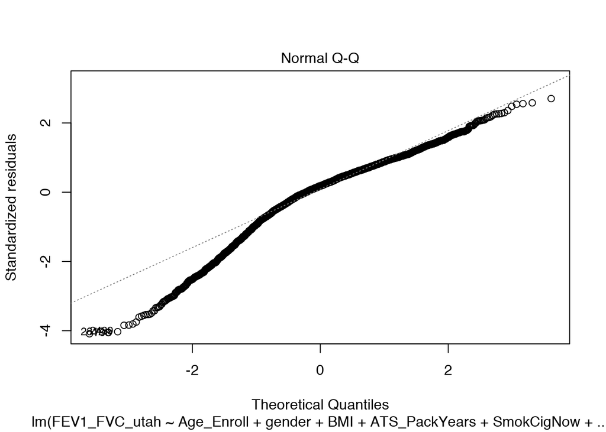

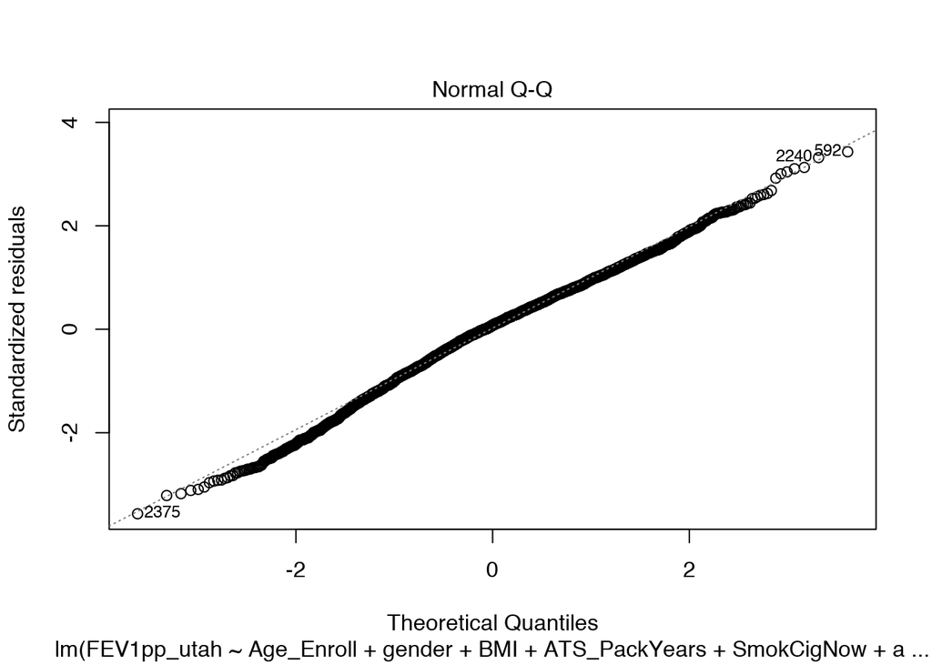

### 7.1.3 Distribution of phenotypes

Is the `FEV1_FVC_utah` phenotype to be log-transformed?

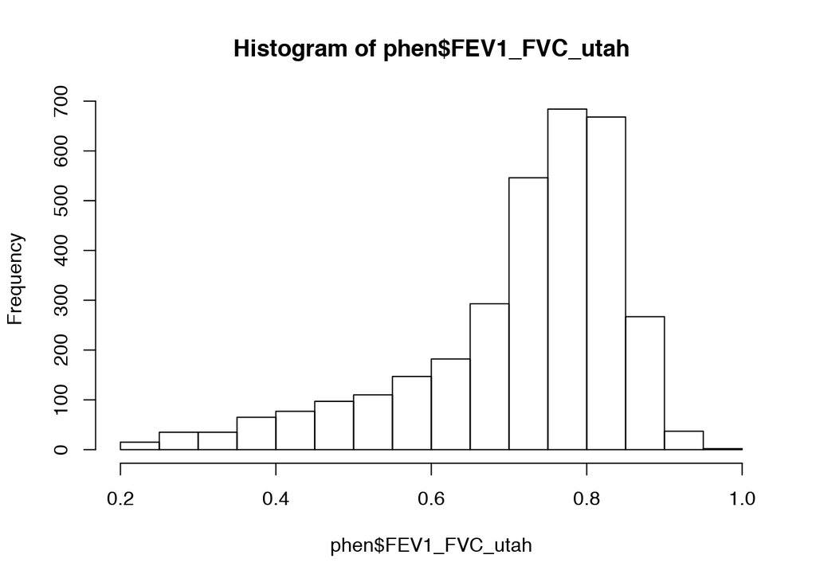

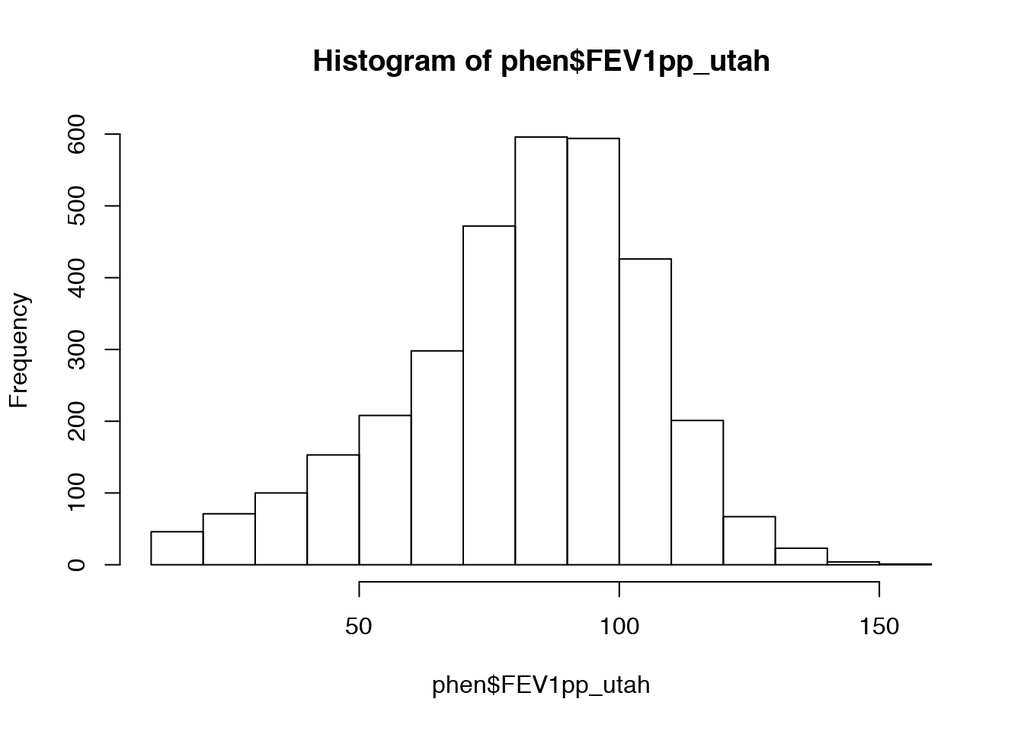

## 7.2 Association results

- Tables of association results are sorted by p-values.
- In Manhattan plots, the red line is genom-wide significant level for testing 37194 segments at `0.05` nominal significance level; the blue line is the significance level used in (Parker et al. 2014), that is `0.05 / 38566`.

### 7.2.1 FEV1-FVC

| acs | estimate | se | pval | chr | pos_mid |
| --- | --- | --- | --- | --- | --- |
| chr12acs104145 | 0.03859369 | 0.008297059 | 3.295437e-06 | 12 | 61024080 |
| chr12acs104149 | 0.03790738 | 0.008290901 | 4.827060e-06 | 12 | 61148975 |
| chr12acs104147 | 0.03735022 | 0.008288232 | 6.593176e-06 | 12 | 61079552 |
| chr12acs104144 | 0.03701642 | 0.008268046 | 7.568322e-06 | 12 | 60920938 |
| chr12acs104143 | 0.03690917 | 0.008270150 | 8.084319e-06 | 12 | 60815310 |
| chr12acs104136 | 0.03681551 | 0.008272924 | 8.582233e-06 | 12 | 60728600 |

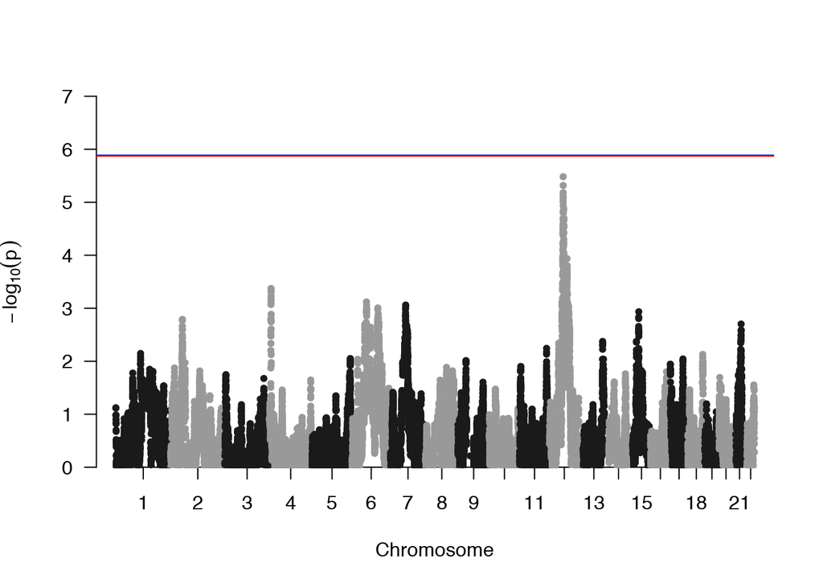

### 7.2.2 FEV1pp

| acs | estimate | se | pval | chr | pos_mid |
| --- | --- | --- | --- | --- | --- |
| chr12acs105001 | 5.688683 | 1.505889 | 0.0001583322 | 12 | 76561612 |
| chr12acs105000 | 5.642922 | 1.505987 | 0.0001789667 | 12 | 76540157 |
| chr12acs105003 | 5.642470 | 1.509117 | 0.0001848115 | 12 | 76727446 |
| chr12acs104990 | 5.591641 | 1.502056 | 0.0001971360 | 12 | 76366430 |
| chr12acs104979 | 5.616315 | 1.510168 | 0.0002000122 | 12 | 76202223 |
| chr12acs105020 | 5.653578 | 1.521338 | 0.0002022507 | 12 | 77026612 |

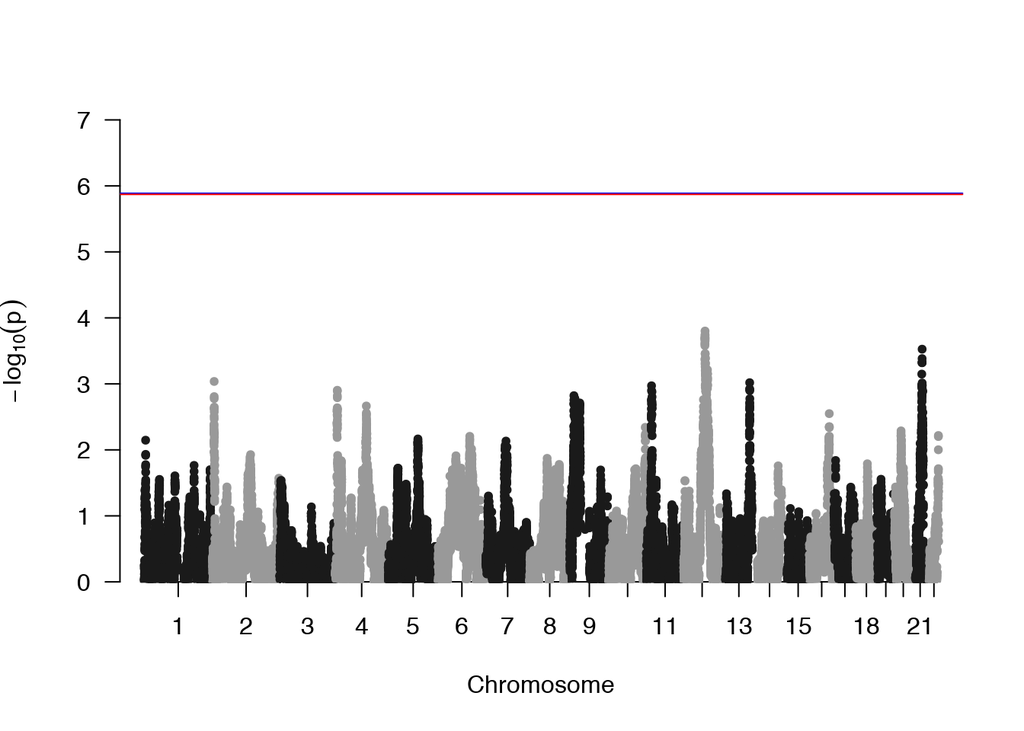

### 7.2.3 Association singnals in Chr 12

This is a replica of the Figure 3 in (Parker et al. 2014), which is a zoom in of the Manhattan plots near the indentified locus at Chr. 12.

- The black line - `FEV1_FVC_utah`.
- The green line - `FEV1pp_utah`.

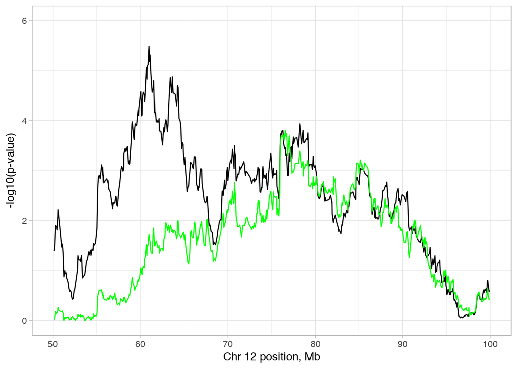

## 7.3 Additional association mapping

Given that residuals in the `FEV1_FVC_utah` model showed a deviation from the normal distribution, we transformed `FEV1_FVC_utah` by inverse-normal and conducted the association mapping again.

| acs | estimate | se | pval | chr | pos_mid |
| --- | --- | --- | --- | --- | --- |
| chr12acs104149 | 0.2537003 | 0.06092558 | 3.125805e-05 | 12 | 61148975 |
| chr12acs104145 | 0.2536316 | 0.06097801 | 3.190914e-05 | 12 | 61024080 |
| chr12acs104266 | 0.2512060 | 0.06127903 | 4.142596e-05 | 12 | 63643106 |
| chr12acs104147 | 0.2476877 | 0.06090789 | 4.770518e-05 | 12 | 61079552 |
| chr12acs104144 | 0.2462963 | 0.06075807 | 5.040923e-05 | 12 | 60920938 |
| chr12acs104258 | 0.2487200 | 0.06148212 | 5.223296e-05 | 12 | 63405996 |

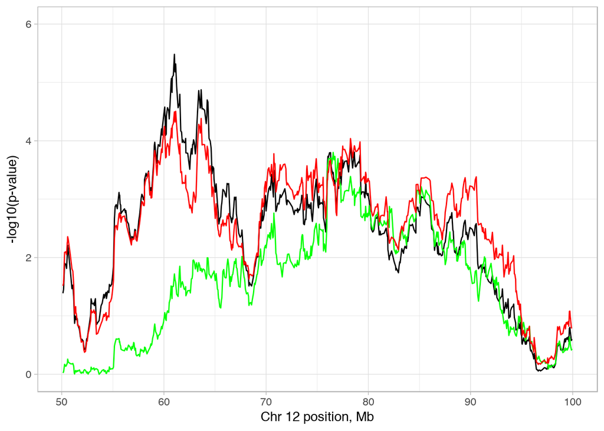

## 7.4 Summary

Summary on ancestry association mapping results for `FEV1-FVC` in two studes, (Parker et al. 2014) and presented here.

[output not shown]

# References

Parker, Margaret M, Marilyn G Foreman, Haley J Abel, Rasika A Mathias, Jacqueline B Hetmanski, James D Crapo, Edwin K Silverman, and Terri H Beaty. 2014. “Admixture Mapping Identifies a Quantitative Trait Locus Associated with Fev1/Fvc in the Copdgene Study.” *Genetic Epidemiology* 38 (7). Wiley Online Library: 652–59.